# Heston Model Volatility Estimation Problem

## 1. Brief Introduction

As we know, volatility plays a critical role in derivatives pricing, risk management and portfolio optimization. One of the compelling approaches to estimate the volatility is the stochastic model. In this research, we try to leverage Heston model to estimate the volatility based on SPX data. By referring to a few academic papers, we first developed computational methods to integrated out the historical volatility in the formula of likelihood function, and then implement the implied volatility into the Heston model. The estimated results are tested in the real market data.

[figure not shown]

## 2. Methodology

- Summary of Two Methods

[figure not shown]

### 2.1 Methodology #1

(Atiya & Wall, 2009)

#### 2.1.1 Data Source

SPX data from Yahoo Finance.

#### 2.1.2 The Heston Model

$s_t$ represents the asset price at time $t$, $v_t$ represents the variance of log_price, if it follows the Heston model, $s_t$ and $v_t$ follow the following SDE:

$$ds_t=\mu s_tdt+\sqrt{v_t}s_tdW_t$$$$dv_t=(\alpha-\beta v_t)dt+\sigma \sqrt{v_t}dZ_t$$$$E(dW_tdZ_t) = \rho dt$$

#### 2.1.3 Parameters

Parameters of the Heston model to fit are $(\mu, \alpha, \beta, \sigma, \rho)$.

- $y_t=ln(s_t)$ is the log price, then it follows a normal distribution
- $\Delta y_{t+1}=y_{t+1}-y_t$ is the log return at time $t+1$
- $\Delta$ = Size of time step
- $\mu$ = Drift term
- $\alpha/\beta$ = Long-run mean
- $\beta$ = Speed of reverting to the mean
- $\sigma$ = Volatility of the volatility
- $\rho=corr(dW_t,dZ_t)$

#### 2.1.4 The Recursive Algorithm

- **S1**: Starting at $t=0$ with a uniform grid for volatility $v_0$, choose a prior distribution for $v_0$: exponential, log-normal, chi-squared
- **S2**: Obtain $v_{t+1} = \sqrt{B^2-C}-B$, where

$$B=-\alpha\Delta-\rho\sigma(\Delta y_{t+1}-\mu\Delta)$$$$C=\alpha^2\Delta^2+2\rho\sigma\alpha\Delta(\Delta y_{t+1}-\mu\Delta)+\sigma^2(\Delta y_{t+1}-\mu\Delta)^2-2v_t^2a\sigma^2(1-\rho^2)\Delta$$

- **S3**: Obtain $L_{t+1} = Constant \times d_t(ab_t)^{-0.25}e^{-2\sqrt{ab_t}}L_t$; Constant = 1e-30 every 50 steps to avoid overflow.
- **S4**: If t<T, return to S2; if t=T, go to S5;
- **S5**: Maximize the integration of $L_T$ with respect to $v_T$ (approximated by computing Riemann sum), i.e.

$$L_T^{'}=\int_{v_T}L_Tdv_T$$

[Exact formulas](https://duyixue.github.io/test/formula_app_YCL.html)

### 2.2 Methodology #2

(Ait-Sahalia & Kimmel, 2007)

#### 2.2.1 Data Source

SPX and VIX data from Yahoo Finance.

#### 2.2.2 The Heston Model

$S_t$ represents the log SPX price at time $t$, $Y_t$ represents the local variance, which is originally unobservable, if it follows the Heston model, $s_t=ln(S_t)$ and $Y_t$ follow the following SDE:

$$d\begin{bmatrix}s_t\\Y_t\end{bmatrix}=\begin{bmatrix}r-d-\frac{1}{2}Y_t\\ \kappa (\gamma-Y_t)\end{bmatrix}dt+ \begin{bmatrix}\sqrt{(1-\rho^2)Y_t}&\rho \sqrt{Y_t}\\0&\sigma \sqrt{Y_t}\end{bmatrix} d\begin{bmatrix}W_1(t)\\W_2(t)\end{bmatrix}$$

where:

- $r=$ Risk free rate. We fix it to 4% in the further calculations.
- $d=$ Dividend yield. We fix it to 1.5% in the further calculations.
- $\kappa$ = The speed of reverting to the mean
- $\gamma$ = The long-run mean

#### 2.2.3 Parameters

Parameters of the Heston model in this representation are $\theta=(\kappa,\gamma,\sigma, \rho)$. And we will use likelihood function to optimize the parameters $\theta$.

#### 2.2.4 The Recursive Algorithm

#### The Likelihood Function

The function is calculated recursively, using the previous step $x$'s information to calculate the $x$ for all time intervals. $$l_X^{(J)}(\Delta,x|x_0;\theta)=-\frac{m}{2}ln(2\pi \Delta)-D_v(x;\theta)+\frac{C_X^{(j_{-1},-1)}(x|x_0;\theta)}{\Delta} +\sum_{k=0}^{J}C_X^{(j_k,k)}(x|x_0;\theta)\frac{\Delta^k}{k!}$$

where:

- $m=$ Dimension of the risk factors(Here we have Log SPX price and VIX)
- $C_X=$ Coefficients
- $D_v(x;\theta)=\frac{1}{2}ln(det[v(x;\theta)])$
- $\nu(x)=\sigma(x)\sigma^{\prime}(x)$

#### 2.2.5 Proxy for $Y_t$

In the paper, the author regards $Y_t$ as latent variable and we can observe option price in the market. We choose VIX to estimate instantaneous variance of SPX index.

- **Method 1** $$Y_t\approx \frac{B\times VIX^2\times(T-t)+A\times(T-t)}{e^{B(T-t)}-1}-\frac{A}{B}$$ where:
  - $A=\kappa\gamma$
  - $B=-\kappa$
  - For $VIX$, we set $T-t=\frac{30}{365}$

$$$$

- **Method 2** $$Y_t\approx VIX^2$$

[Exact formulas](https://duyixue.github.io/test/formula_app_YCL.html)

## 3. Fit Model in Simulation Data

### 3.1 Model 1

#### 3.1.1 Filtering Problem

Try a simple simulation and have a look at the result first.

- **Theta:** $\theta = (\mu, \alpha, \beta, \sigma, \rho)^T = (0.025, 0.3, 3, 0.25, -0.8)^T$
- **Starting Points:** $v_0 = 0.03,y_0=7.5$
- **Generating Function: the transition probability density**  
  $p(y_{t+1},v_{t+1}|y_t,v_t) = N(\mu_{t+1},\Sigma_{t+1})$, where  
  $\mu_{t+1} = \begin{bmatrix}y_t+(\mu-\frac{v_t}{2}\Delta)\\v_t + (\alpha-\beta v_t)\Delta\end{bmatrix}$,  
  $\Sigma_{t+1} = v_t\Delta\begin{bmatrix}1 & \rho\sigma\\\rho\sigma & \sigma^2\end{bmatrix}$

**The simulation data is shown below:**

[Detailed code](https://duyixue.github.io/test/paper_1_mntncty_XC.html)

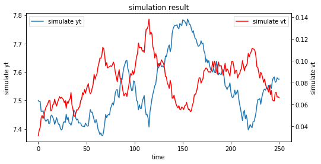

```python
ax1.plot(yt_sim,label='simulate yt')
ax2.plot(vt_sim,c='red',label='simulate vt')
```

**Comparison between simulated volatility and calculated volatility from model 1:**

**Attention:** We need to import the original guess about the theta to find out the volatility path. If we put the true theta, the simulated volatility is quite similar compared to the calculated volatility.  
However, if I add a small noise(0.5*normal distribution) to theta, the result is much worse than before.

Computed using the real theta: $\theta = (\mu, \alpha, \beta, \sigma, \rho)^T = (0.025, 0.3, 3, 0.25, -0.8)^T$

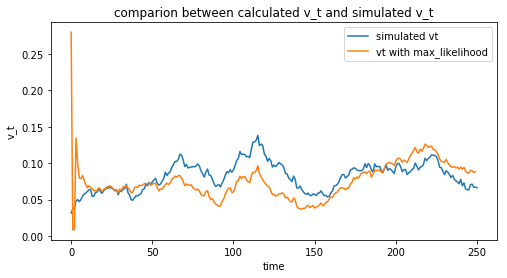

```python
plt.plot(vt_sim,label = "simulated vt")
plt.plot(vt_with_max_l,label = "vt with max_likelihood")
```

Computed using the real theta + a small noise: $\theta = (\mu, \alpha, \beta, \sigma, \rho)^T = (0.029, 0.51, 3.06, 0.33, -0.30)^T$

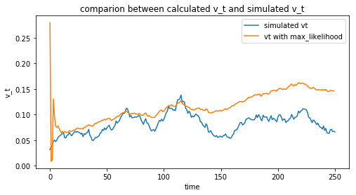

```python
plt.plot(vt_sim,label = "simulated vt")
plt.plot(vt_with_max_l,label = "vt with max_likelihood")
```

#### 3.1.2 Test of monotonicity

#### Results:

$\alpha,\beta$ seem to be close to the true values. While $\mu,\sigma,\rho$ have some extreme points but not in the correct places.

- **True Theta value for simulated data:**  
  $\theta = (\mu, \alpha, \beta, \sigma, \rho)^T = (0.025, 0.3, 3, 0.25, -0.8)^T$
- **Objective Functions:**  
  From the equation 35, $L^{'}_T = \int_{v_T}p(v_T,y_{1:T}|y_0,\theta)dv_T$  
  Here we calculate the intergral using the formula: $\sum_{v_T}\Delta v_T * L_T(v_T)$
- **It is the result for a single simulation. To test the stability of the estimation, we repeat the simulation and change the number of obeservations in the next part.**

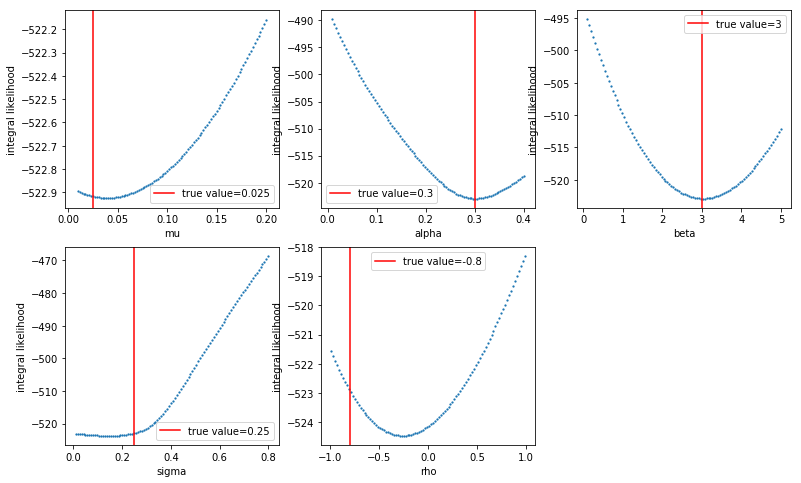

```python
plt.scatter(mu_list, res_list1, s=1.5)
plt.scatter(alpha_list, res_list2, s=1.5)
plt.scatter(beta_list, res_list3, s=1.5)
plt.scatter(sigma_list, res_list4, s=1.5)
plt.scatter(rho_list, res_list5, s=1.5)
```

#### 3.1.3 Parameter Estimation Result

Restrict $\theta$ so that model 1 and model 2 share similar Heston model parameters:

$\theta = (\mu, \alpha, \beta, \sigma, \rho)^T = (0.025, 0.3, 3, 0.25, -0.8)^T$

Simulate one-year data: $n = 250$ and run the algorithm to estimate optimal parameters. Repeat 200 times and then estimate the parameter estimate.

- **True Value**: the original value of parameters in simulation
- **Estimate Mean**: mean value of 200 parameter estimates
- **Mean Bias**: different between Estimate Mean and True Value
- **Estimate Standard Deviation**: standard deviation of 200 parameter estimates

[Detailed code](https://duyixue.github.io/test/paper_1_simulation_YXD.html)

**n = 250**

```python
summary_res_2 = compute_descpt_stats(theta, sim_res_2)
summary_res_2
```

|  | True Value | Estimate Mean | Mean_Bias | Estimate Standard Deviation |
| --- | --- | --- | --- | --- |
| mu | 0.0250 | 0.0789 | 0.0539 | 0.0765 |
| alpha | 0.3000 | 0.4061 | 0.1061 | 0.0975 |
| beta | 3.0000 | 2.6383 | -0.3617 | 1.5090 |
| sigma | 0.2500 | 0.5874 | 0.3374 | 0.1415 |
| rho | -0.8000 | -0.3279 | 0.4721 | 0.2129 |

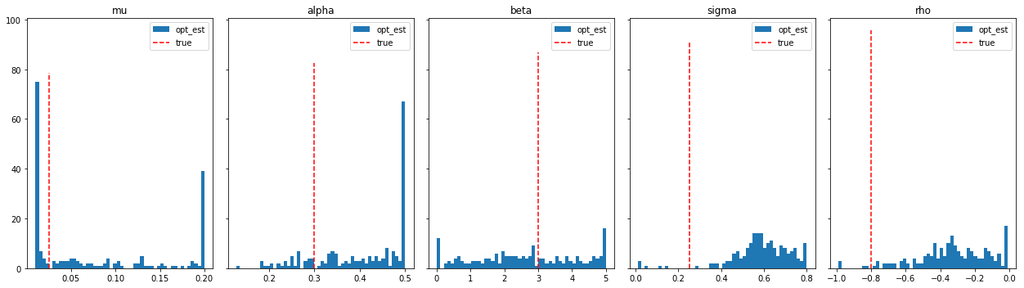

```python
plot_hist(theta, sim_res_2)
```

#### 3.1.4 Varying the number of total observations

**n = 500**

```python
summary_res_1 = compute_descpt_stats(theta, sim_res_1)
summary_res_1
```

|  | True Value | Estimate Mean | Mean_Bias | Estimate Standard Deviation |
| --- | --- | --- | --- | --- |
| mu | 0.0250 | 0.0804 | 0.0554 | 0.0754 |
| alpha | 0.3000 | 0.3737 | 0.0737 | 0.1078 |
| beta | 3.0000 | 2.5372 | -0.4628 | 1.3195 |
| sigma | 0.2500 | 0.5161 | 0.2661 | 0.1476 |
| rho | -0.8000 | -0.3961 | 0.4039 | 0.2306 |

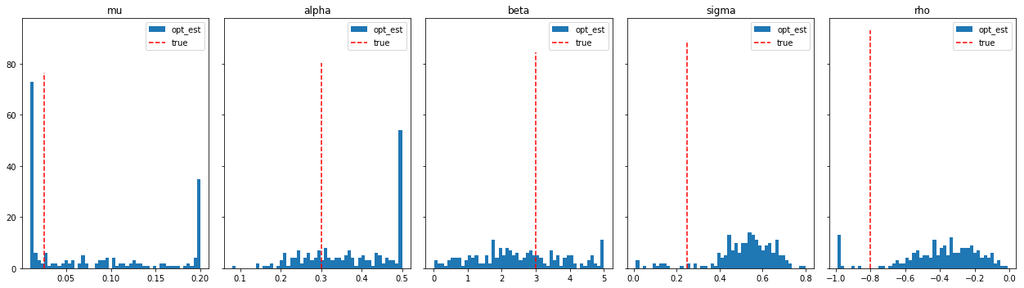

```python
plot_hist(theta, sim_res_1)
```

**n = 1000**

```python
summary_res_3 = compute_descpt_stats(theta, sim_res_3)
summary_res_3
```

|  | True Value | Estimate Mean | Mean_Bias | Estimate Standard Deviation |
| --- | --- | --- | --- | --- |
| mu | 0.0250 | 0.0387 | 0.0137 | 0.0514 |
| alpha | 0.3000 | 0.3581 | 0.0581 | 0.1018 |
| beta | 3.0000 | 2.7016 | -0.2984 | 1.2935 |
| sigma | 0.2500 | 0.4220 | 0.1720 | 0.1614 |
| rho | -0.8000 | -0.5168 | 0.2832 | 0.3024 |

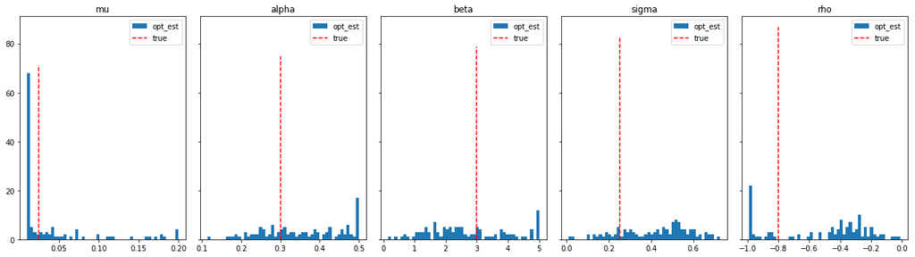

```python
plot_hist(theta, sim_res_3)
```

**Some facts:**

#### 3.1.5 Analysis of the model

**Possible Reasons about the problems in the algorithm**

- The simulated(real) v_t is not necessary the path with the maximum likelihood,
- The time interval is not long enough for the calculation.
- There may exist some problems when the likelihood function is estimated in the paper.
- The result depends on the parameters we choose in the algorithm. For example, the starting point of v0, the length of time in total, the prior function of v0 and the theta we choose in the algorithm.

### 3.2 Model 2

Try a simple simulation and have a look at the result first.

- **Theta:** $\theta = (\kappa, \gamma, \sigma, \rho)^T$
- **Starting Points:** $Y_0 = 0.013,s_0=7.1$
- **Generating Function: the transition probability density** $p(s_{t+1},Y_{t+1}|s_t,Y_t) = N(\mu_{t+1},\Sigma_{t+1})$, where  
  $\mu_{t+1} = \begin{bmatrix}s_t+(r-d-0.5{Y_t}\Delta )\\Y_t + \kappa(\gamma-Y_t)\Delta\end{bmatrix}$,  
  $\Sigma_{t+1} = Y_t\Delta \begin{bmatrix}1 & \rho\sigma\\\rho\sigma & \sigma^2\end{bmatrix}$

We use $\theta = (\kappa, \gamma, \sigma, \rho)^T = (3, 0.05, 0.15, -0.6)^T$ here as a simple simulation example

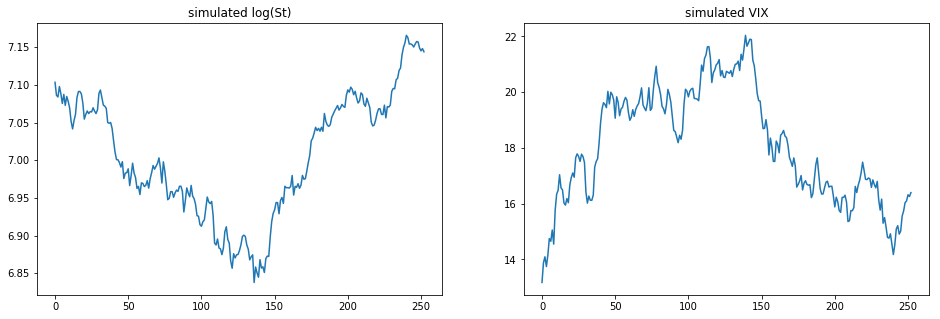

```python
plt.figure(figsize=(16, 5))
plt.subplot(1, 2, 1)
plt.plot(sim_y_series)
plt.title('simulated log(St)')
plt.subplot(1, 2, 2)
plt.plot(sim_vix)
plt.title('simulated VIX');
```

Restrict $\theta$ so that model 1 and model 2 share similar Heston model parameters:

$\theta = (\kappa, \gamma, \sigma, \rho)^T = (3, 0.1, 0.25, -0.8)^T$

Simulate one-year data: $n = 250$ and run the algorithm to estimate optimal parameters. Repeat 200 times and then estimate the parameter estimate.

See below for sample data simulated:

[Detailed code](https://duyixue.github.io/test/paper_2_YNC.html)

**n = 250; simply use VIX as the proxy for $Y_t$**

```python
summary_vix.dropna().set_index(pd.Index(["kappa","gamma","sigma","rho"]))
```

|  | True Value | Estimate Mean | Mean_Bias | Estimate Standard Deviation |
| --- | --- | --- | --- | --- |
| kappa | 3.00 | 3.787668 | -0.787668 | 1.664262 |
| gamma | 0.10 | 0.106949 | -0.006949 | 0.090324 |
| sigma | 0.25 | 0.258482 | -0.008482 | 0.009011 |
| rho | -0.80 | -0.828600 | 0.028600 | 0.017333 |

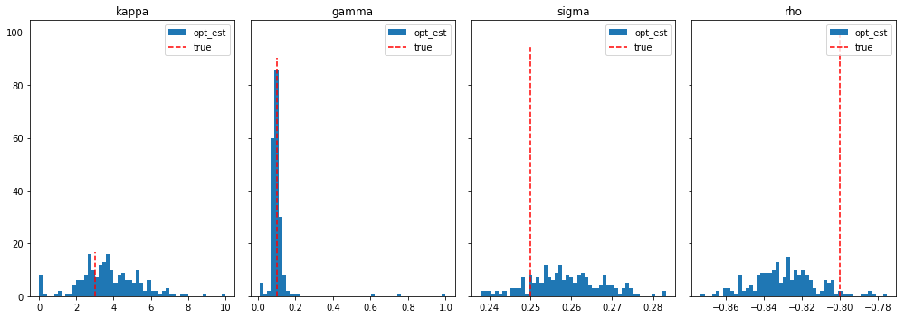

```python
plot_hist(theta,mc_res)
```

**n = 500; simply use VIX as the proxy for $Y_t$**

```python
summary_vix_500.dropna().set_index(pd.Index(["kappa","gamma","sigma","rho"]))
```

|  | True Value | Estimate Mean | Mean_Bias | Estimate Standard Deviation |
| --- | --- | --- | --- | --- |
| kappa | 3.00 | 3.908478 | 0.908478 | 1.642660 |
| gamma | 0.10 | 0.100723 | 0.000723 | 0.027469 |
| sigma | 0.25 | 0.257996 | 0.007996 | 0.009305 |
| rho | -0.80 | -0.829860 | -0.029860 | 0.016620 |

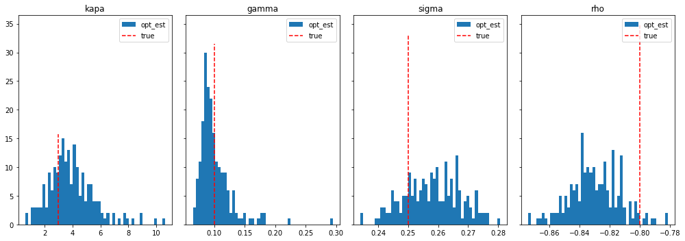

```python
plot_hist(theta, mc_res_500)
```

### Some facts:

```python
res = np.array([0.0,0.0,0.0,0.0])
for i in range(10):
    sim_res = simulation(y0_sim, v0_sim, theta, n,delta, sub_interval=30)
    sim_y_series = sim_res[:, 0]
    sim_v = np.array(sim_res[:, 1])
    sim_vix = np.sqrt(sim_v)*100
    theta0 = (3,0.1,0.3,-0.2)
    bound = ((0,10),(0.01,10),(0.1,0.6),(-0.99,-0.01))  # theta = (kai,gamma,sigma,rho)
    min_opt_res = minimize(sim_cost_1, theta0, bounds = bound,method='SLSQP',
                           tol=1e-11, options={'maxiter': 300})
    res += min_opt_res.x
    print(i, min_opt_res.x, min_opt_res.fun, sim_cost(theta))  # print index, optimal results, optimal cost, true parameter cost
```

```
0 [ 3.   0.1  0.3 -0.2] 10000.0 -2514.7920164952466
```

```
1 [ 6.78568313e-13  1.27247679e-01  3.54589509e-01 -6.71552737e-01] -2426.4378481940166 -2396.920625820411
2 [ 3.   0.1  0.3 -0.2] -1857.6960629182156 -2413.4298370033644
```

```
3 [ 2.10425481e-14  1.30410232e-02  3.21814639e-01 -6.37565707e-01] -2520.2950324767653 -2498.6556114266405
```

```
4 [ 2.27397853e-15  1.22020613e-01  3.29493184e-01 -6.53526122e-01] -2540.245058668853 -2475.35745357439
5 [ 3.   0.1  0.3 -0.2] 10000.0 -2411.8497221806397
6 [ 3.   0.1  0.3 -0.2] 10000.0 -2475.9187409179135
7 [ 3.   0.1  0.3 -0.2] 10000.0 -2385.3641163635
8 [ 1.93299700e-08  2.38983561e-02  3.05250186e-01 -6.26374787e-01] -2436.7048109401208 -2426.4085010746253
9 [ 3.   0.1  0.3 -0.2] 10000.0 -2445.3322758567265
```

**Therefore, try Basinhopping to avoid getting stuck in one point:**

```python
theta = (3, 0.1, 0.25, -0.8)
n = 250
mc_res_vix_exp = pd.DataFrame(columns = ["kappa","gamma","sigma","rho"])
for i in range(10):
    sim_res = simulation(y0_sim, v0_sim, theta, n,delta, sub_interval=30)
    sim_y_series = sim_res[:, 0]
    sim_v = np.array(sim_res[:, 1])
    sim_vix = 100*np.sqrt(generate_sim_vix(theta,sim_v))
    theta0 = (3,0.1,0.3,-0.2)
    bound = ((0,20),(0.01,1),(0.1,0.6),(-0.85,-0.01))  # theta = (kai,gamma,sigma,rho)
    min_opt_res_vix_exp = basinhopping(sim_cost_1, theta0, niter=10, minimizer_kwargs={'method': 'SLSQP', 'bounds': bound})
    mc_res_vix_exp = mc_res_vix_exp.append(dict(zip(mc_res_vix_exp.columns,min_opt_res.x)), ignore_index = True)
    print(i,min_opt_res_vix_exp.x)  # print index, optimal results, optimal cost, true parameter cost
```

```
0 [ 5.03763697e-15  1.00000000e-02  2.66214190e-01 -8.20706275e-01]
```

```
1 [ 1.73835100e-06  4.64532764e-01  2.67678179e-01 -8.38071135e-01]
2 [ 5.56718724e-06  1.88551522e-02  2.66545681e-01 -8.35302221e-01]
3 [ 1.02001740e-15  4.63712749e-02  2.59077266e-01 -7.85644797e-01]
4 [ 8.62070686e-15  1.00000000e-02  2.72254092e-01 -8.04436911e-01]
5 [ 2.01845918e-15  1.81897601e-01  2.72442955e-01 -8.23922431e-01]
6 [ 0.04897947  1.          0.26814171 -0.82729671]
7 [ 0.01340345  1.          0.26229595 -0.83461009]
8 [ 9.58615215e-15  4.23974986e-01  2.55096474e-01 -8.50000000e-01]
9 [ 1.23512311e-15  4.13905908e-01  2.55179142e-01 -8.34262466e-01]
```

**Within the time limit, we were only able to run 176 simulations.**

```python
summary_vix.dropna().set_index(pd.Index(["kappa","gamma","sigma","rho"]))
```

|  | True Value | Estimate Mean | Mean_Bias | Estimate Standard Deviation |
| --- | --- | --- | --- | --- |
| kappa | 3.00 | 0.024648 | 2.975352 | 0.059108 |
| gamma | 0.10 | 0.531921 | -0.431921 | 0.434856 |
| sigma | 0.25 | 0.260042 | -0.010042 | 0.011899 |
| rho | -0.80 | -0.823868 | 0.023868 | 0.018101 |

### Some facts:

- $\sigma$ and $\rho$ seem to be 'optimized' well, while the optimal estimates of $\gamma$ are not that stable and are around the boundary in some circumstances.
- The optimizer does nothing good for $\kappa$, we can say...
- However, the efficiency of Basinhopping (we only require niter = 10) is super low. Therefore we cannot provide enough simulations to test stability and consistency of the algorithm. When we increase niter, which is too time-consuming, the optimal solutions will get improved.

## 4. Fit SPX and VIX data

### 4.1 Model 1

The algorithm is too poor to be applied to real data. So this model is not recommended, and we did not fit SPX data for Model 1.

### 4.2 Model 2

Test model 2 on real market data. Selected time periods are:

- 2018_2019
- 2017_2019
- 2007_2009
- 1990_2004

**See below for comparison of the vol level during 2007-2009 and 2017-2019:**

[Detailed code](https://duyixue.github.io/test/paper_2_YNC.html)

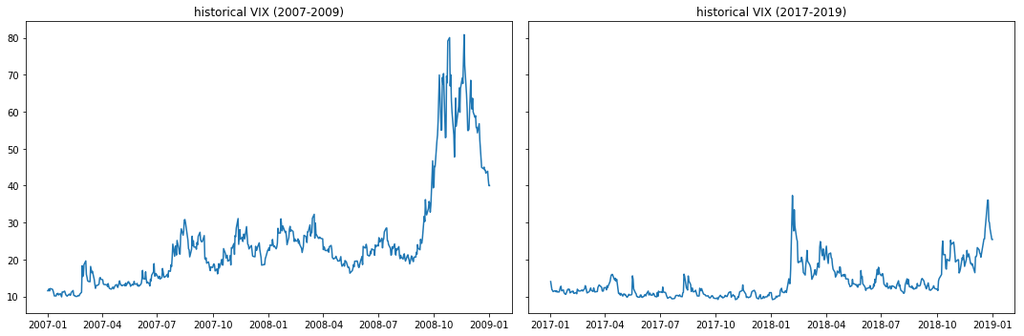

```python
fig, axs = plt.subplots(1, 2, sharey=True, tight_layout=True, figsize=(15,5))
axs[0].plot(vix_df["2007-01-01":"2009-01-01"])
axs[0].title.set_text("historical VIX (2007-2009)")
axs[1].plot(vix_df["2017-01-01":"2019-01-01"])
axs[1].title.set_text("historical VIX (2017-2019)");
```

First, we try to replicate the optimization in the paper. In the paper, the author uses the same time period and his result is kappa = 5.07, gamma = 0.0457, sigma = 0.48,rho = -0.767,lambda1 = 3.9. We try both the basinhopping and local optimizer, the result is not far away from the author's. Then, we try to do the past year's optimization.

**See below for optimal estimates:**

```python
real_time_res
```

|  | Kappa | sqrt(gamma) | sigma | rho |
| --- | --- | --- | --- | --- |
| 2018-2019 | 31.841967 | 0.175829 | 0.900000 | -0.603736 |
| 2017-2019 | 37.271800 | 0.151156 | 0.900000 | -0.726523 |
| 2007-2009 | 5.777443 | 0.267124 | 0.900000 | -0.762061 |
| 1990-2004 | 5.936774 | 0.227000 | 0.625322 | -0.831208 |

**Some facts:**

- $\sigma$ does not seem to be optimized.
- Compared to the result of *Ait-Sahalia & Kimmel, 2007*, the results are reasonable.
- Reasons for differences: not tuning $\lambda_1$ and $\lambda_2$, which are two risk pricings made to differentiate $\mathbb{Q}$-model and $\mathbb{P}$-model

## 5.Conclusion

### 5.1 Model 1

- The algorithm is not a good fit in the real data based on the given likihood function

### 5.3 Future Work

- Stability of model estimates
- Efficiency of computation
- Model 1: mathematical derivation when $v_{t+1}$ is not gauranteed to be solved by the formulas (NaN)
- Model 2
  - Find a better proxy for $Y_t$, rather than simply using VIX data
  - Incorporate $\lambda_1$ and $\lambda_2$ in the optimization